# Index

Jonathan Schuster

08/10/2020

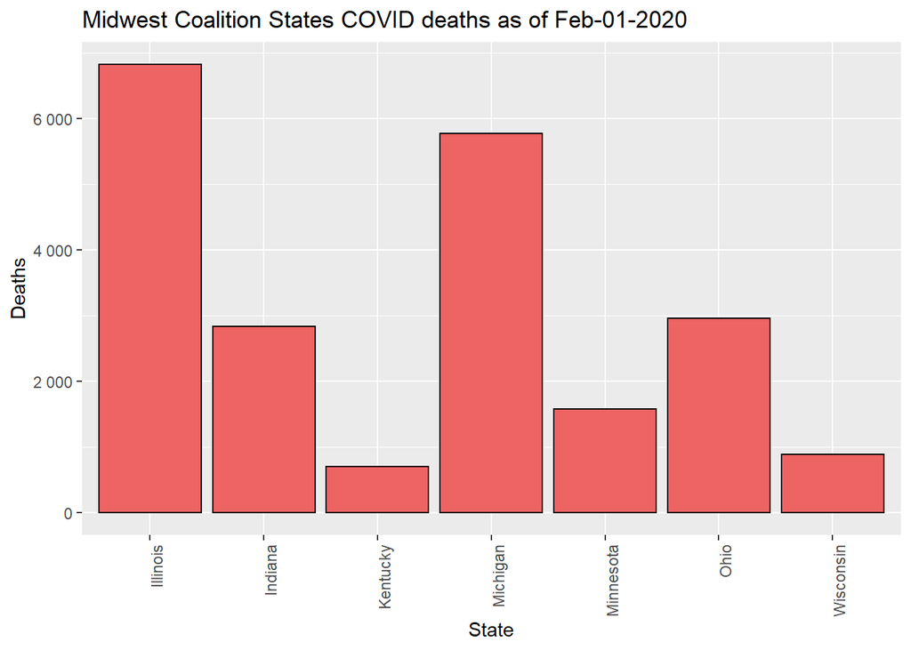

**Description:**

The data used for this graph comes from the CDC. Specifically, https://data.cdc.gov/NCHS/Provisional-COVID-19-Death-Counts-by-Place-of-Deat/uggs-hy5q will take you directly to the data I used. I used the columns “State” and “COVID19 Deaths”. Here I was trying to show the total amount of deaths coming from the seven states in the coalition. I’ll be comparing to seven states with similar population sizes to the states shown above. Comparing overall deaths to each other to see if the coalition had fewer total deaths compared to states without the coalition.

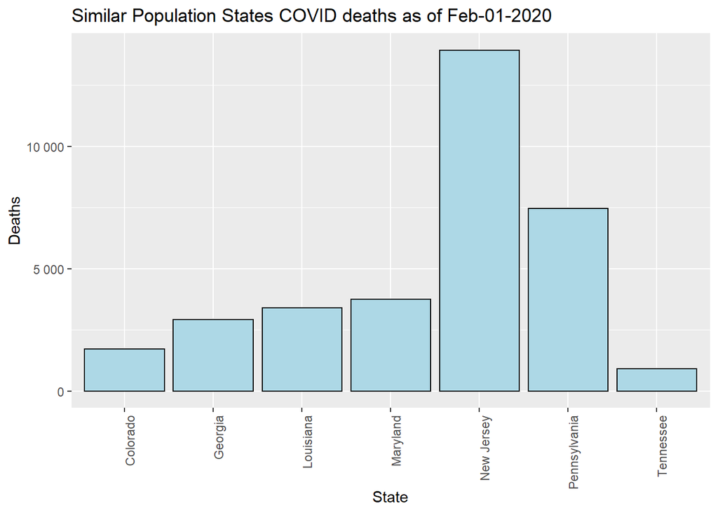

**Description:**

Same dataset as used above. The difference is the seven states I elected to use based on similar populations to the midwest coalition states. I used the same columns to evaluate if more total deaths were seen compared to the coalition states. While a huge discrepancy doesn’t exist between the coalition states compared to the noncoalition states it does seem like the coalition did see overall less deaths.

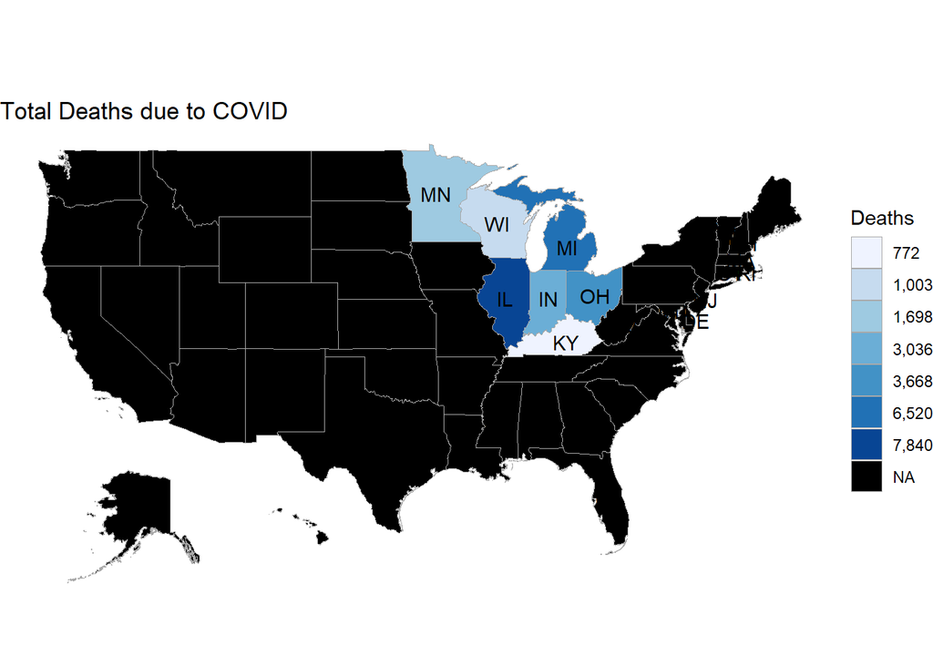

**Choropleth 1:** Total Deaths from States in the Midwest Coalition

**Description:**

This table uses a different dataset, but it still originates from the CDC. The direct url for this dataset is https://www.cdc.gov/covid-data-tracker/#cases. We used this dataset to make choropleths for Assignment 07. However, I changed the filtering options and manipulated to just show the states I’m interested in. It gives the same data as the other dataset (roughly), but gives a more visual representation for the viewer. I just liked this graph better.